# Reproducible Research: Peer Assessment 1

## Loading and preprocessing the data

- Download zip file if not alredy present
- Unzip if if not present
- Load Data

```r
archiveFile <- "activity_data.zip"
if(!file.exists(archiveFile)) {
    archiveURL <- "https://d396qusza40orc.cloudfront.net/repdata%2Fdata%2Factivity.zip"
    download.file(url=archiveURL,destfile=archiveFile,method="curl")
}

if(!(file.exists("activity.csv"))) { unzip(archiveFile) }

activity = read.csv("activity.csv")
```

Summary of activity data

```r
summary(activity)
```

```
##      steps                date          interval
##  Min.   :  0.00   2012-10-01:  288   Min.   :   0.0
##  1st Qu.:  0.00   2012-10-02:  288   1st Qu.: 588.8
##  Median :  0.00   2012-10-03:  288   Median :1177.5
##  Mean   : 37.38   2012-10-04:  288   Mean   :1177.5
##  3rd Qu.: 12.00   2012-10-05:  288   3rd Qu.:1766.2
##  Max.   :806.00   2012-10-06:  288   Max.   :2355.0
##  NA's   :2304     (Other)   :15840
```

## What is mean total number of steps taken per day?

Calculate the total number of steps taken per day

```r
totalSteps <- aggregate(steps ~ date, data = activity, sum, na.rm = TRUE)

summary(totalSteps)
```

```
##          date        steps
##  2012-10-02: 1   Min.   :   41
##  2012-10-03: 1   1st Qu.: 8841
##  2012-10-04: 1   Median :10765
##  2012-10-05: 1   Mean   :10766
##  2012-10-06: 1   3rd Qu.:13294
##  2012-10-07: 1   Max.   :21194
##  (Other)   :47
```

Make a histogram of the total number of steps taken each day

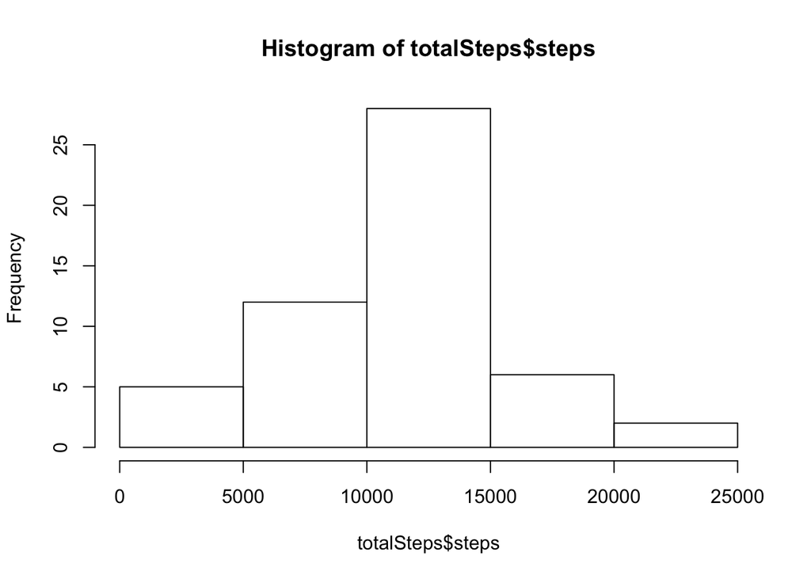

```r
hist(totalSteps$steps)
```

Calculate and report the mean and median of the total number of steps taken per day

```r
options(scipen = 1, digits = 2) #Format output
meanSteps = mean(totalSteps$steps)

medianSteps = median(totalSteps$steps)
```

Mean steps is **10766.19** and median steps is **10765**

## What is the average daily activity pattern?

Make a time series plot

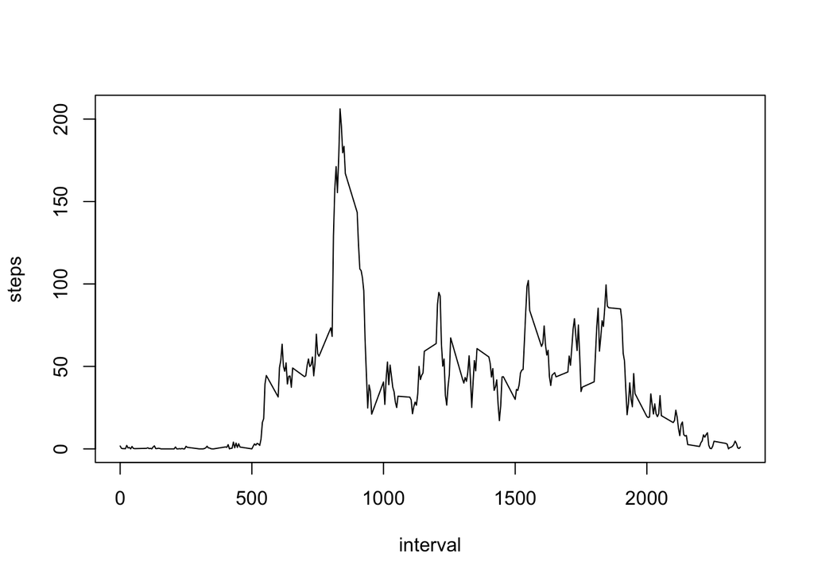

```r
stepsInterval <- aggregate(steps ~ interval, data = activity, mean, na.rm = TRUE)
plot(steps ~ interval, data = stepsInterval, type = "l")
```

```r
maxStepsInterval = stepsInterval[which.max(stepsInterval$steps), ]$interval
```

Max steps occured in the **835** interval

## Imputing missing values

Total number of missing values

```r
missing = sum(is.na(activity$steps))
```

There are **2304** values

Missing values will be filled by using the mean for the interval in question.

```r
interval2steps <- function(interval) {
    stepsInterval[stepsInterval$interval == interval, ]$steps
}

activityFilled <- activity
count = 0
for (i in 1:nrow(activityFilled)) {
    if (is.na(activityFilled[i, ]$steps)) {
        activityFilled[i, ]$steps <- interval2steps(activityFilled[i, ]$interval)
        count = count + 1
    }
}
```

A total of **2304** valus were filled.

Make a histogram of the total number of steps with filled data

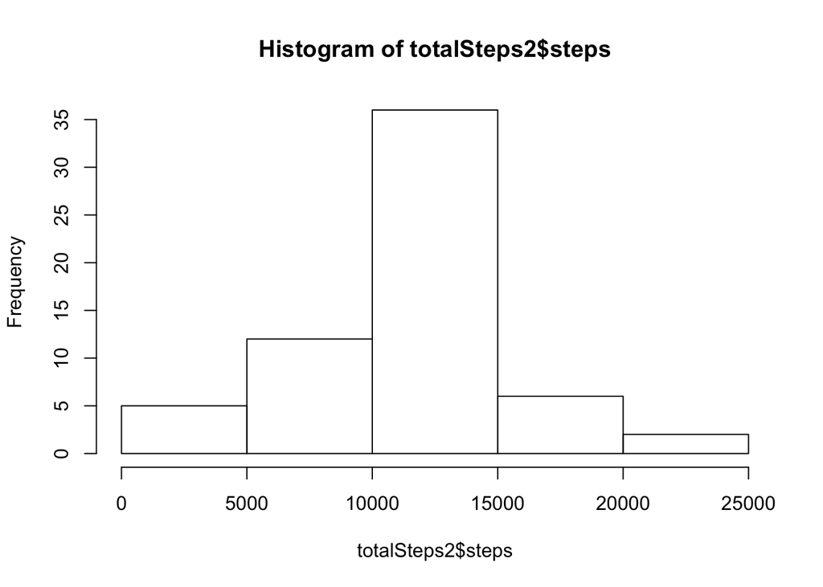

```r
totalSteps2 <- aggregate(steps ~ date, data = activityFilled, sum)
hist(totalSteps2$steps)
```

Calculate and report the mean and median

```r
meanStepsFilled = mean(totalSteps2$steps)

medianStepsFilled = median(totalSteps2$steps)
```

Mean steps is **10766.19** and median steps is **10766.19**

Do these values differ from the estimates from the first part of the assignment?

Mean values are the same since mean was used to fill in data.

What is the impact of imputing missing data on the estimates of the total daily number of steps?

The median value shows a slight change up.

## Are there differences in activity patterns between weekdays and weekends?

Create a new factor variable in the dataset with two levels – “weekday” and “weekend”

```r
activityFilled$day = ifelse(as.POSIXlt(as.Date(activityFilled$date))$wday%%6 ==
    0, "weekend", "weekday")
# For Sunday and Saturday : weekend, Other days : weekday
activityFilled$day = factor(activityFilled$day, levels = c("weekday", "weekend"))
```

Make a panel plot containing a time series plot

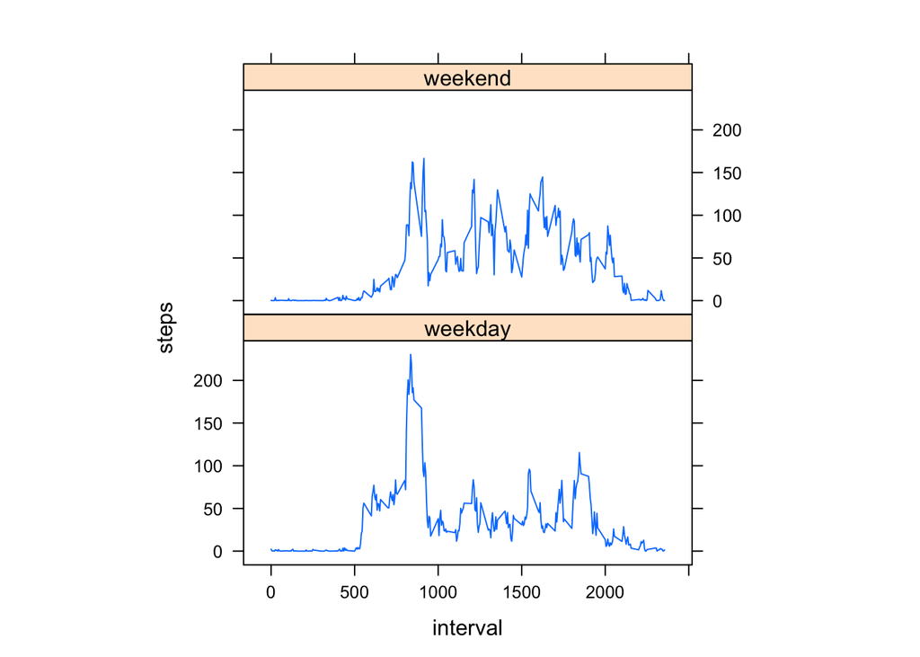

```r
stepsInterval2 = aggregate(steps ~ interval + day, activityFilled, mean)
library(lattice)
xyplot(steps ~ interval | factor(day), data = stepsInterval2, aspect = 1/2,
    type = "l")
```

Weekend activity appears to be overall higher, while weekday activity has a spike in the A.M. and generally lower as the day moves on.